[智能助教](https://www.doubao.com/chat/7372912125423173667?type=1)

# Matplotlib数据可视化：基本图表绘制

## 教学目标

本课程旨在教授如何使用Matplotlib绘制基本图表，包括折线图、柱状图和散点图。课程将结合实际案例，帮助学生将抽象数据转化为直观可视化结果。

## 1. Matplotlib基础讲解

### 1.1 什么是数据可视化？

**核心概念**：数据可视化是将抽象数据通过图形化手段呈现的过程，帮助人们更直观地理解数据特征和规律。

**意义**：

- 历史研究：展示人口变迁、经济发展趋势
- 社会学：呈现调查统计数据
- 心理学：可视化实验结果
- 文学研究：文本数据分析展示

### 1.2 Matplotlib简介

**定义**：Matplotlib是Python中最基础、最常用的数据可视化库，可以创建各种静态、动态和交互式的图表。

**特点**：

- 类似MATLAB的绘图接口，学习曲线平缓
- 高度可定制化
- 支持多种输出格式
- 与NumPy、Pandas等科学计算库完美兼容

### 1.3 安装

- 方法一

pip install matplotlib

- 方法二 快速安装

pip install matplotlib -i https://pypi.tuna.tsinghua.edu.cn/simple

### 1.4 基本绘图流程讲解

任何Matplotlib图表都遵循以下基本流程：

1. 准备数据
2. 创建画布(figure)
3. 绘制图表
4. 添加标题、标签等修饰
5. 显示或保存图表

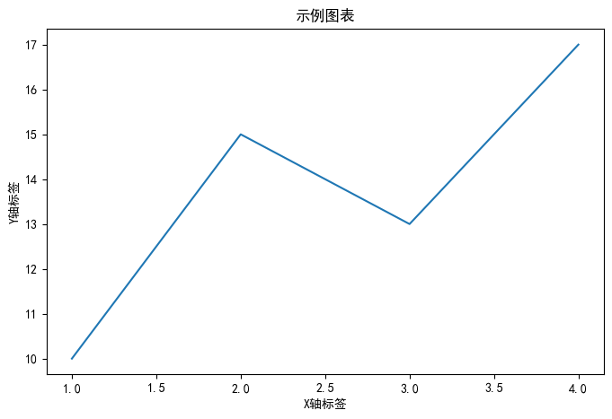

```python
import matplotlib.pyplot as plt
plt.rcParams['font.sans-serif'] = ['SimHei']  # Windows系统
# 或['Arial Unicode MS']  # Mac系统
plt.rcParams['axes.unicode_minus'] = False
# # 准备数据
x = [1, 2, 3, 4]
y = [10, 15, 13, 17]

# 创建画布
plt.figure(figsize=(8,5))

# 绘制图表
plt.plot(x, y)

# 添加修饰
plt.title("示例图表")
plt.xlabel("X轴标签")
plt.ylabel("Y轴标签")

# 显示图表
plt.show()
```

## 2. 折线图 (Line Plot) 详解

### 2.1 折线图适用场景

显示数据随时间变化的趋势。

最佳使用时机：

- 显示数据随时间的变化趋势
- 比较多个序列的变化规律
- 展示连续数据的波动情况

案例：

- 年度GDP增长趋势
- 人口出生率变化
- 图书出版数量变化
- 大学生就业率变化

### 2.2 代码逐行解析

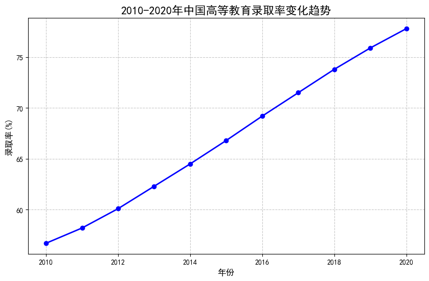

```python
import numpy as np
import matplotlib.pyplot as plt
plt.rcParams['font.sans-serif'] = ['SimHei']  # Windows系统
# 或['Arial Unicode MS']  # Mac系统
plt.rcParams['axes.unicode_minus'] = False
# 创建数据
years = np.arange(2010, 2021)  # 使用NumPy生成2010-2020的年份序列
enrollment_rates = [56.7, 58.2, 60.1, 62.3, 64.5, 66.8, 69.2, 71.5, 73.8, 75.9, 77.8]  # 对应年份的录取率
# 创建折线图
plt.figure(figsize=(10, 6))  # 设置图形大小(宽10英寸，高6英寸)
plt.plot(
    years,                   # X轴数据
    enrollment_rates,        # Y轴数据
    marker='o',              # 数据点标记为圆形
    color='b',               # 线条颜色为蓝色
    linestyle='-',           # 实线样式
    linewidth=2              # 线宽为2磅
)
# 添加标题和标签
plt.title('2010-2020年中国高等教育录取率变化趋势', fontsize=16)
plt.xlabel('年份', fontsize=12)
plt.ylabel('录取率(%)', fontsize=12)
# 添加网格线
plt.grid(
    True,                   # 显示网格
    linestyle='--',         # 虚线样式
    alpha=0.7               # 透明度70%
)
# 显示图表
plt.show()
```

### 2.3 关键参数讲解

- marker：数据点标记样式（o圆形，s方形，^三角形等）
- color：支持颜色名称('b'=blue)、十六进制值('#FF5733')或RGB元组
- linestyle：线条样式（-实线，--虚线，:点线等）
- linewidth：线条粗细（以磅为单位）

### 2.4 练习

任务：绘制过去10年某国家/地区GDP增长率的折线图

思考题：

- 如果数据点很多，是否还需要marker？为什么？
- 如何在同一图表中绘制多条折线进行比较？
- 当X轴标签重叠时该如何处理？

## 3. 柱状图 (Bar Chart) 详解

### 3.1 柱状图适用场景

最佳使用时机：

- 比较不同类别间的数值差异
- 显示离散数据的分布情况
- 展示部分与整体的关系

案例：

- 不同专业学生人数对比
- 各地区文化遗产数量
- 各出版社学术著作出版量
- 不同年龄段阅读习惯调查

### 3.2 代码逐行解析

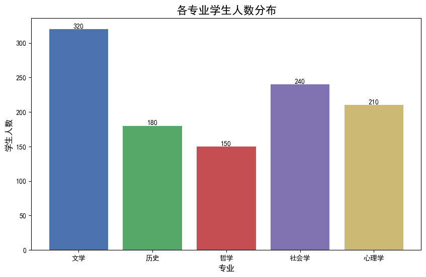

```python
import matplotlib.pyplot as plt
plt.rcParams['font.sans-serif'] = ['SimHei']  # Windows系统
# 或['Arial Unicode MS']  # Mac系统
plt.rcParams['axes.unicode_minus'] = False

# 创建数据
majors = ['文学', '历史', '哲学', '社会学', '心理学']
students = [320, 180, 150, 240, 210]

# 创建柱状图
plt.figure(figsize=(10, 6))
bars = plt.bar(
    majors,                 # X轴类别
    students,               # 柱体高度
    color=['#4C72B0', '#55A868', '#C44E52', '#8172B2', '#CCB974']  # 自定义颜色
)

# 添加数值标签
for bar in bars:
    height = bar.get_height()  # 获取每个柱体的高度
    plt.text(
        bar.get_x() + bar.get_width()/2.,  # 文本X位置(柱体中心)
        height,                            # 文本Y位置
        f'{height}',                      # 显示数值
        ha='center',                      # 水平居中
        va='bottom'                       # 垂直底部对齐
    )

# 添加标题和标签
plt.title('各专业学生人数分布', fontsize=16)
plt.xlabel('专业', fontsize=12)
plt.ylabel('学生人数', fontsize=12)
```

### 3.3 关键参数讲解

- width：控制柱体宽度（默认0.8）
- align：对齐方式（'center'或'edge'）
- alpha：透明度（0-1之间）
- edgecolor：柱体边框颜色

### 3.4 练习

任务：绘制某城市不同区域图书馆数量的柱状图(询问大模型)

思考题：

- 当类别名称很长时，如何避免X轴标签重叠？
- 如何绘制堆叠柱状图展示更多维度信息？
- 水平柱状图在什么情况下更适合使用？

## 4. 散点图 (Scatter Plot) 详解

### 4.1 散点图适用场景

最佳使用时机：

- 展示两个变量之间的相关性
- 发现数据中的聚类或异常值
- 显示数据分布密度

案例：

- 阅读时间与成绩关系
- 收入水平与文化消费关系
- 城市人口与公共设施数量关系
- 社交媒体使用与幸福感关系

### 4.2 代码逐行解析

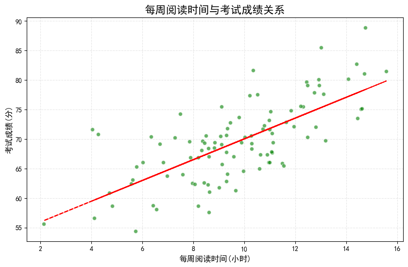

```python
import matplotlib.pyplot as plt
plt.rcParams['font.sans-serif'] = ['SimHei']  # Windows系统
# 或['Arial Unicode MS']  # Mac系统
plt.rcParams['axes.unicode_minus'] = False

# 创建模拟数据
np.random.seed(42)  # 设置随机种子确保可重复性
reading_hours = np.random.normal(10, 3, 100)  # 生成100个正态分布的阅读时间数据
exam_scores = 50 + 2*reading_hours + np.random.normal(0, 5, 100)  # 生成与阅读时间相关的成绩数据

# 创建散点图
plt.figure(figsize=(10, 6))
plt.scatter(
    reading_hours,         # X轴数据
    exam_scores,           # Y轴数据
    color='green',         # 点颜色
    alpha=0.6,            # 透明度
    edgecolors='w'        # 点边缘颜色
)
# 添加趋势线
z = np.polyfit(reading_hours, exam_scores, 1)  # 一元线性拟合
p = np.poly1d(z)                              # 生成拟合函数
plt.plot(reading_hours, p(reading_hours), "r--")  # 绘制红色虚线趋势线
# 添加标题和标签
plt.title('每周阅读时间与考试成绩关系', fontsize=16)
plt.xlabel('每周阅读时间(小时)', fontsize=12)
plt.ylabel('考试成绩(分)', fontsize=12)
plt.grid(True, linestyle='--', alpha=0.3)  # 添加半透明虚线网格
```

### 4.3 关键参数讲解

- s：控制点的大小
- c：可以传入数组实现颜色映射
- marker：点的形状（默认圆形）
- cmap：颜色映射方案

### 4.4 练习

任务：绘制社交媒体使用时间与幸福指数关系的散点图

思考题：

- 如何通过散点图发现异常值？
- 当数据点过多重叠时，如何改进可视化效果？
- 如何添加颜色维度表示第三个变量？

# 综合练习

根据iris_np.csv数据，完成下面的任务

### 题目1：折线图

要求：绘制不同鸢尾花物种（setosa, versicolor, virginica）的萼片长度（Sepal.Length）随样本索引变化的折线图，用不同颜色区分物种，并添加图例和坐标轴标签。

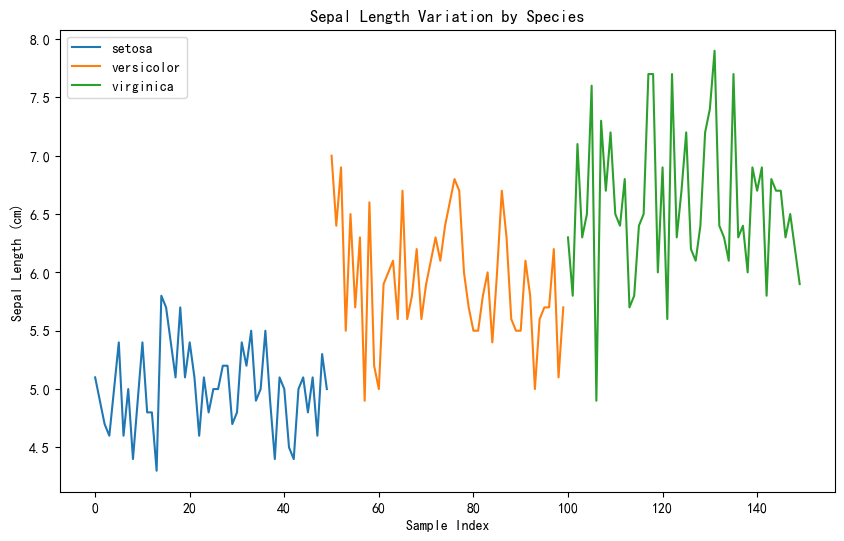

```python
import matplotlib.pyplot as plt
import pandas as pd

# 假设数据已加载为DataFrame，列名正确
df = pd.read_csv('C:/Users/Zhouq/Desktop/iris_np.csv')

plt.figure(figsize=(10, 6))
for species in df['Species'].unique():
    species_data = df[df['Species'] == species]
    plt.plot(species_data.index, species_data['Sepal.Length'], label=species)

plt.xlabel('Sample Index')
plt.ylabel('Sepal Length (cm)')
plt.title('Sepal Length Variation by Species')
plt.legend()
plt.show()
```

### 题目2：柱状图

要求：比较三个物种在四个特征（萼片长度、萼片宽度、花瓣长度、花瓣宽度）上的平均值，绘制四个子图，每个子图显示一个特征的物种对比柱状图。

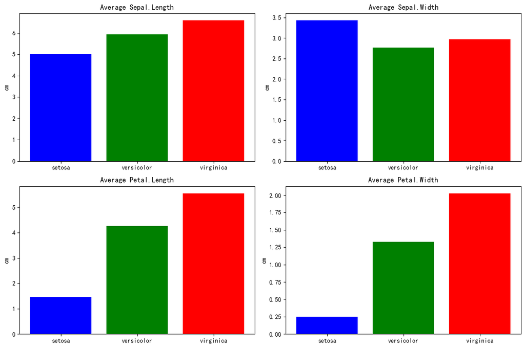

```python
import matplotlib.pyplot as plt
import pandas as pd

df = pd.read_csv('iris_np.csv')
means = df.groupby('Species').mean()  # 计算各物种均值

features = ['Sepal.Length', 'Sepal.Width', 'Petal.Length', 'Petal.Width']
plt.figure(figsize=(12, 8))
for i, feature in enumerate(features, 1):
    plt.subplot(2, 2, i)
    plt.bar(means.index, means[feature], color=['blue', 'green', 'red'])
    plt.title(f'Average {feature}')
    plt.ylabel('cm')

plt.tight_layout()
plt.show()
```

## 题目3：散点图

要求：绘制萼片长度（Sepal.Length）与花瓣长度（Petal.Length）的散点图，点颜色表示不同物种，添加图例、标题和轴标签。

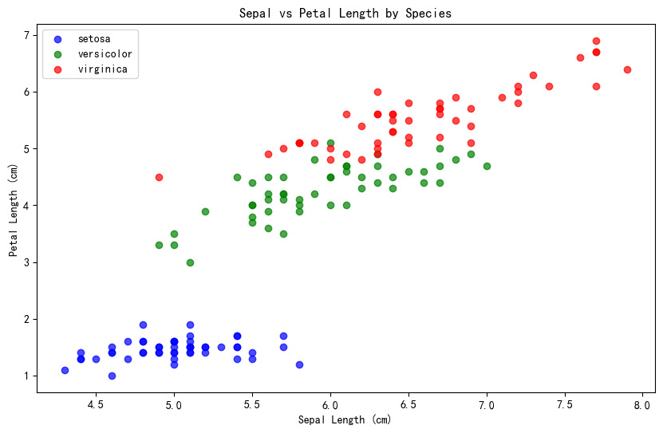

```python
import matplotlib.pyplot as plt
import pandas as pd

df = pd.read_csv('iris_np.csv')
colors = {'setosa': 'blue', 'versicolor': 'green', 'virginica': 'red'}

plt.figure(figsize=(10, 6))
for species, color in colors.items():
    species_data = df[df['Species'] == species]
    plt.scatter(species_data['Sepal.Length'], species_data['Petal.Length'],
                color=color, label=species, alpha=0.7)

plt.xlabel('Sepal Length (cm)')
plt.ylabel('Petal Length (cm)')
plt.title('Sepal vs Petal Length by Species')
plt.legend()
plt.show()
```

## 5. 综合应用与作业

请参考上述示例，完成相应图表作业，注意根据数据特性选择合适的图表类型，并合理美化图表。

### 5.1 图表选择指南

| 图表类型 | 适用场景 | 人文社科示例 |
| --- | --- | --- |
| 折线图 | 趋势分析 | 人口变化、经济指标 |
| 柱状图 | 比较分类 | 不同地区文化设施数量 |
| 散点图 | 关系分析 | 教育投入与成果关系 |

### 5.2 作业详细要求

#### 折线图作业

1. **数据要求**：
   - 收集真实数据（推荐国家统计局网站）
   - 时间跨度≥5个时间点
   - 数据需包含完整时间序列

### 5.3 常见问题解答

Q1：如何保存高清图表？

```python
plt.savefig('output.png',
           dpi=300,                   # 分辨率
           bbox_inches='tight',       # 去除白边
           transparent=True)          # 透明背景(可选)
```

Q2：中文显示异常怎么办？

```python
# 解决方案一：指定中文字体
plt.rcParams['font.sans-serif'] = ['SimHei']  # Windows
# plt.rcParams['font.sans-serif'] = ['Arial Unicode MS']  # Mac

# 解决方案二：使用具体字体路径
# import matplotlib.font_manager as fm
# font_path = 'your_chinese_font.ttf'#替换自己的字体
# font_prop = fm.FontProperties(fname=font_path)
# plt.title("标题", fontproperties=font_prop)
```

Q3：如何调整图例样式？

```python
plt.legend(
    loc='upper left',          # 位置设置
    frameon=False,            # 去除边框
    ncol=2,                   # 分列显示
    prop={'size': 10}         # 字体大小
)
```

Q4：图表元素太多太拥挤？

```python
plt.tight_layout()  # 自动调整布局
# 或手动调整
plt.subplots_adjust(
    left=0.1,
    right=0.9,
    top=0.9,
    bottom=0.2
)
```